# 代码示例

```python
# -*- coding:utf-8 -*-
import pandas as pd
import numpy as np
from sklearn.model_selection import train_test_split
from sklearn import metrics
from sklearn import tree
from sklearn.svm import SVC
from sklearn.ensemble import GradientBoostingClassifier
%matplotlib inline
import matplotlib.pyplot as plt #导入图库
from matplotlib.pylab import*
from sklearn.metrics import precision_recall_curve
from sklearn.metrics import roc_curve,auc
from sklearn.decomposition import PCA
from sklearn.pipeline import Pipeline
from sklearn import preprocessing
```

```python
data=pd.read_csv(r"c:/users/administrator/desktop/datamining/car.csv",encoding="gb2312",index_col=0)#导入数据
```

```python
col=data.columns#查看数据变量
```

```python
len(data)#数据量
```

```
124
```

```python
data.info()#数据的描述
```

```
<class 'pandas.core.frame.DataFrame'>
Int64Index: 124 entries, 1 to 124
Data columns (total 15 columns):
销售类型             124 non-null object
销售模式             124 non-null object
汽车销售平均毛利         124 non-null float64
维修毛利             124 non-null float64
企业维修收入占销售收入比重    124 non-null float64
增值税税负            124 non-null float64
存货周转率            124 non-null float64
成本费用利润率          124 non-null float64
整体理论税负           124 non-null float64
整体税负控制数          124 non-null float64
办牌率              124 non-null float64
单台办牌手续费收入        124 non-null float64
代办保险率            124 non-null float64
保费返还率            124 non-null float64
输出               124 non-null object
dtypes: float64(12), object(3)
memory usage: 15.5+ KB
```

```python
data.describe()#数据的描述
```

|  | 汽车销售平均毛利 | 维修毛利 | 企业维修收入占销售收入比重 | 增值税税负 | 存货周转率 | 成本费用利润率 | 整体理论税负 | 整体税负控制数 | 办牌率 | 单台办牌手续费收入 | 代办保险率 | 保费返还率 |
| --- | --- | --- | --- | --- | --- | --- | --- | --- | --- | --- | --- | --- |
| count | 124.000000 | 124.000000 | 124.000000 | 124.000000 | 124.000000 | 124.000000 | 124.000000 | 124.000000 | 124.000000 | 124.000000 | 124.000000 | 124.000000 |
| mean | 0.023709 | 0.154894 | 0.068717 | 0.008287 | 11.036540 | 0.174839 | 0.010435 | 0.006961 | 0.133499 | 0.016387 | 0.169976 | 0.039165 |
| std | 0.103790 | 0.414387 | 0.158254 | 0.013389 | 12.984948 | 1.121757 | 0.032753 | 0.008926 | 0.227417 | 0.032510 | 0.336220 | 0.065910 |
| min | -1.064600 | -3.125500 | 0.000000 | 0.000000 | 0.000000 | -1.000000 | -0.181000 | -0.007000 | 0.000000 | 0.000000 | 0.000000 | -0.014800 |
| 25% | 0.003150 | 0.000000 | 0.000000 | 0.000475 | 2.459350 | -0.004075 | 0.000725 | 0.000000 | 0.000000 | 0.000000 | 0.000000 | 0.000000 |
| 50% | 0.025100 | 0.156700 | 0.025950 | 0.004800 | 8.421250 | 0.000500 | 0.009100 | 0.006000 | 0.000000 | 0.000000 | 0.000000 | 0.000000 |
| 75% | 0.049425 | 0.398925 | 0.079550 | 0.008800 | 15.199725 | 0.009425 | 0.015925 | 0.011425 | 0.194175 | 0.020000 | 0.138500 | 0.081350 |
| max | 0.177400 | 1.000000 | 1.000000 | 0.077000 | 96.746100 | 9.827200 | 0.159300 | 0.057000 | 0.877500 | 0.200000 | 1.529700 | 0.270000 |

```python
for i in range(2,14):#将连续特征离散化，分为4类，分类临界为4分位数
    data.loc[data.iloc[:,i]>np.percentile(data.iloc[:,i],75) ,col[i]]=40;
    data.loc[(data.iloc[:,i]<=np.percentile(data.iloc[:,i],75)) & (data.iloc[:,i]>np.percentile(data.iloc[:,i],50)) ,col[i]]=30;
    data.loc[(data.iloc[:,i]<=np.percentile(data.iloc[:,i],50)) & (data.iloc[:,i]>np.percentile(data.iloc[:,i],25)) ,col[i]]=20;
    data.loc[data.iloc[:,i]<=np.percentile(data.iloc[:,i],25) ,col[i]]=10
```

```python
data.销售类型.value_counts()
```

```
国产轿车     64
进口轿车     17
大客车      13
其它       10
卡车及轻卡     7
微型面包车     6
商用货车      5
工程车       2
Name: 销售类型, dtype: int64
```

```python
xslx_class=data.销售类型.value_counts().index
```

```python
data.销售类型=data.销售类型.map({"国产轿车":0,"进口轿车":1,"大客车":2,"其它":3,"卡车及轻卡":4,"微型面包车":5,"商用货车":6,"工程车":7})#将字符串转化为数值型方便分类
```

```python
data.销售模式.value_counts()
```

```
4S店           76
一级代理商         20
二级及二级以下代理商    16
多品牌经营店         7
其它             5
Name: 销售模式, dtype: int64
```

```python
xsms_class=data.销售模式.value_counts().index
```

```python
data.销售模式=data.销售模式.map({"4S店":0,"一级代理商":1,"二级及二级以下代理商":2,"多品牌经营店":3,"其它":4})#上同
```

```python
data.输出=data.输出.map({"正常":1,"异常":0})#将kabel映射成数值型数据，目的最终分类
```

```python
data.describe()#数据的描述
```

|  | 销售类型 | 销售模式 | 汽车销售平均毛利 | 维修毛利 | 企业维修收入占销售收入比重 | 增值税税负 | 存货周转率 | 成本费用利润率 | 整体理论税负 | 整体税负控制数 | 办牌率 | 单台办牌手续费收入 | 代办保险率 | 保费返还率 | 输出 |
| --- | --- | --- | --- | --- | --- | --- | --- | --- | --- | --- | --- | --- | --- | --- | --- |
| count | 124.000000 | 124.000000 | 124.000000 | 124.000000 | 124.000000 | 124.000000 | 124.000000 | 124.000000 | 124.000000 | 124.000000 | 124.000000 | 124.000000 | 124.000000 | 124.000000 | 124.000000 |
| mean | 1.411290 | 0.750000 | 25.000000 | 23.306452 | 23.548387 | 24.919355 | 25.000000 | 24.758065 | 24.838710 | 23.467742 | 19.435484 | 19.274194 | 19.274194 | 18.629032 | 0.572581 |
| std | 1.917027 | 1.130688 | 11.225696 | 12.540781 | 12.375793 | 11.152743 | 11.225696 | 11.223068 | 11.224528 | 12.431559 | 13.270324 | 12.889360 | 13.262416 | 13.210902 | 0.496711 |
| min | 0.000000 | 0.000000 | 10.000000 | 10.000000 | 10.000000 | 10.000000 | 10.000000 | 10.000000 | 10.000000 | 10.000000 | 10.000000 | 10.000000 | 10.000000 | 10.000000 | 0.000000 |
| 25% | 0.000000 | 0.000000 | 17.500000 | 10.000000 | 10.000000 | 17.500000 | 17.500000 | 17.500000 | 17.500000 | 10.000000 | 10.000000 | 10.000000 | 10.000000 | 10.000000 | 0.000000 |
| 50% | 0.000000 | 0.000000 | 25.000000 | 25.000000 | 25.000000 | 25.000000 | 25.000000 | 20.000000 | 20.000000 | 25.000000 | 10.000000 | 10.000000 | 10.000000 | 10.000000 | 1.000000 |
| 75% | 2.000000 | 1.000000 | 32.500000 | 32.500000 | 32.500000 | 30.000000 | 32.500000 | 32.500000 | 32.500000 | 32.500000 | 32.500000 | 30.000000 | 32.500000 | 32.500000 | 1.000000 |
| max | 7.000000 | 4.000000 | 40.000000 | 40.000000 | 40.000000 | 40.000000 | 40.000000 | 40.000000 | 40.000000 | 40.000000 | 40.000000 | 40.000000 | 40.000000 | 40.000000 | 1.000000 |

```python
mpl.rcParams['font.sans-serif'] = ['SimHei']#设置中文字体
mpl.rcParams['axes.unicode_minus'] = False#设置识别负号
```

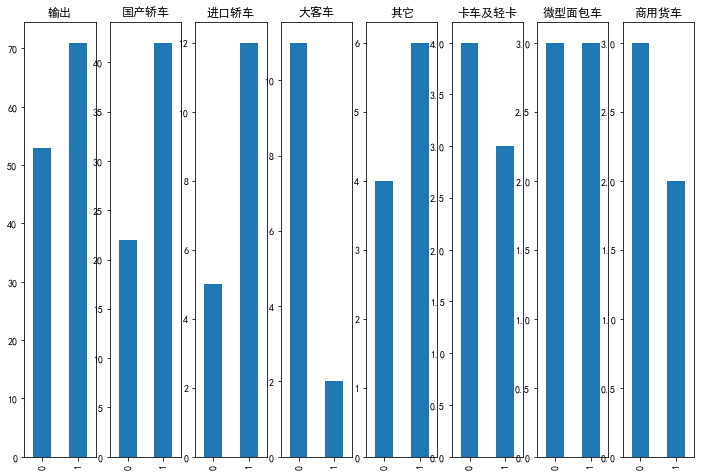

```python
fig,axes=plt.subplots(1,8,figsize=(12,8))#查看销售类型不同是否影响输出
data.输出.value_counts().sort_index().plot(kind = 'bar',ax=axes[0],title=u'输出');#这里加上sort_index()是为了统一index的顺序
for i in range(1,8):
    data[data.销售类型==i-1].输出.value_counts().sort_index().plot(kind = 'bar', ax =axes[i],title=xslx_class[i-1]);
```

通过描述统计图发现，除了微型面包车的纳税情况（55开）没有区别之外，其他的属性都对整体纳税有影响

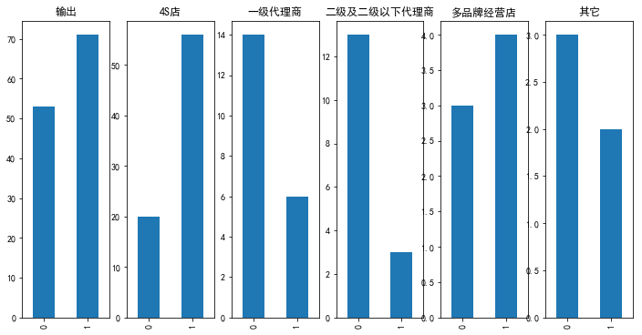

```python
fig,axes=plt.subplots(1,6,figsize=(12,6))#查看销售模式不同是否影响输出
data.输出.value_counts().sort_index().plot(kind = 'bar',ax=axes[0],title=u'输出');#这里加上sort_index()是为了统一index的顺序
for i in range(1,6):
    data[data.销售模式==i-1].输出.value_counts().sort_index().plot(kind = 'bar', ax =axes[i],title=xsms_class[i-1]);
```

通过描述统计图发现，销售模式属性都对整体纳税有影响

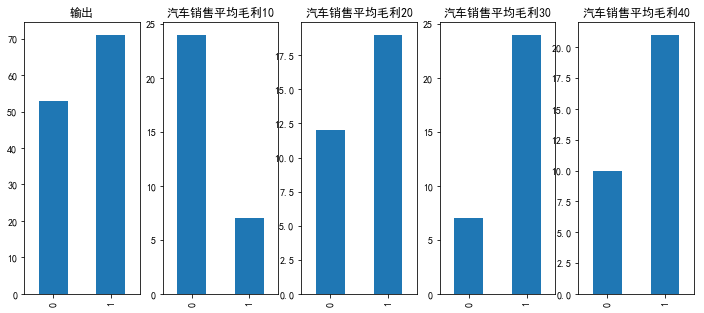

```python
fig,axes=plt.subplots(1,5,figsize=(12,5))#查看汽车销售平均毛利不同是否影响输出
data.输出.value_counts().sort_index().plot(kind = 'bar',ax=axes[0],title=u'输出');#这里加上sort_index()是为了统一index的顺序
for i in range(1,5):
    data[data.汽车销售平均毛利==i*10].输出.value_counts().sort_index().plot(kind = 'bar', ax =axes[i],title=u'汽车销售平均毛利{}'.format(i*10));
```

上同

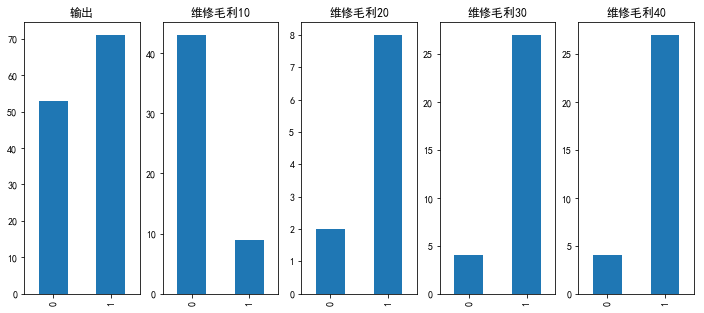

```python
fig,axes=plt.subplots(1,5,figsize=(12,5))#查看维修毛利不同是否影响输出
data.输出.value_counts().sort_index().plot(kind = 'bar',ax=axes[0],title=u'输出');#这里加上sort_index()是为了统一index的顺序
for i in range(1,5):
    data[data.维修毛利==i*10].输出.value_counts().sort_index().plot(kind = 'bar', ax =axes[i],title=u'维修毛利{}'.format(i*10));
```

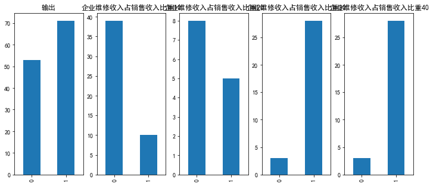

```python
fig,axes=plt.subplots(1,5,figsize=(12,5))#查看汽车企业维修收入占销售收入比重不同是否影响输出
data.输出.value_counts().sort_index().plot(kind = 'bar',ax=axes[0],title=u'输出');#这里加上sort_index()是为了统一index的顺序
for i in range(1,5):
    data[data.企业维修收入占销售收入比重==i*10].输出.value_counts().sort_index().plot(kind = 'bar', ax =axes[i],title=u'企业维修收入占销售收入比重{}'.format(i*10));
```

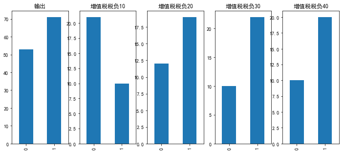

```python
fig,axes=plt.subplots(1,5,figsize=(12,5))#查看增值税税负不同是否影响输出
data.输出.value_counts().sort_index().plot(kind = 'bar',ax=axes[0],title=u'输出');#这里加上sort_index()是为了统一index的顺序
for i in range(1,5):
    data[data.增值税税负==i*10].输出.value_counts().sort_index().plot(kind = 'bar', ax =axes[i],title=u'增值税税负{}'.format(i*10));
```

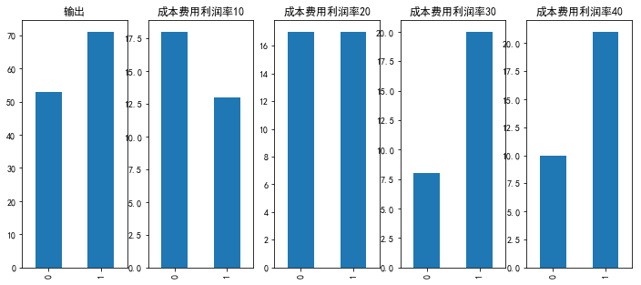

```python
fig,axes=plt.subplots(1,5,figsize=(12,5))#查看成本费用利润率不同是否影响输出
data.输出.value_counts().sort_index().plot(kind = 'bar',ax=axes[0],title=u'输出');#这里加上sort_index()是为了统一index的顺序
for i in range(1,5):
    data[data.成本费用利润率==i*10].输出.value_counts().sort_index().plot(kind = 'bar', ax =axes[i],title=u'成本费用利润率{}'.format(i*10));
```

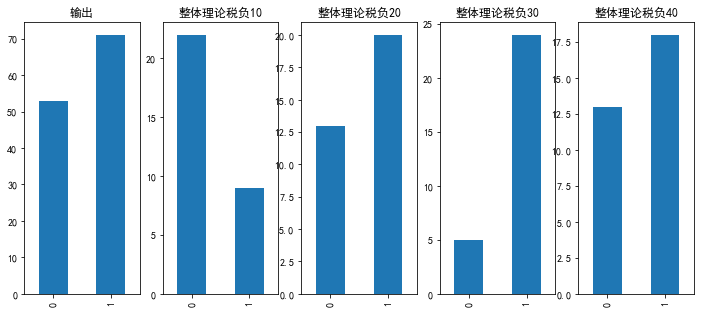

```python
fig,axes=plt.subplots(1,5,figsize=(12,5))#查看整体理论税负不同是否影响输出
data.输出.value_counts().sort_index().plot(kind = 'bar',ax=axes[0],title=u'输出');#这里加上sort_index()是为了统一index的顺序
for i in range(1,5):
    data[data.整体理论税负==i*10].输出.value_counts().sort_index().plot(kind = 'bar', ax =axes[i],title=u'整体理论税负{}'.format(i*10));
```

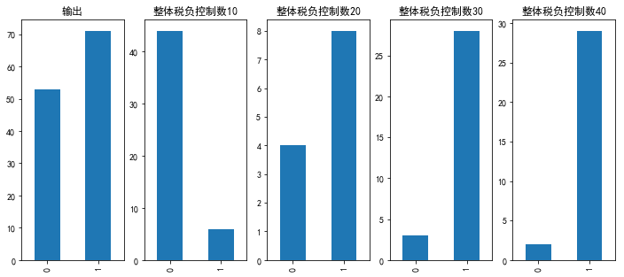

```python
fig,axes=plt.subplots(1,5,figsize=(12,5))#查看整体税负控制数不同是否影响输出
data.输出.value_counts().sort_index().plot(kind = 'bar',ax=axes[0],title=u'输出');#这里加上sort_index()是为了统一index的顺序
for i in range(1,5):
    data[data.整体税负控制数==i*10].输出.value_counts().sort_index().plot(kind = 'bar', ax =axes[i],title=u'整体税负控制数{}'.format(i*10));
```

```python
data.单台办牌手续费收入=data.单台办牌手续费收入.map({10.0:10.0,30.0:20.0,40.0:30.0});#数据转换
data.代办保险率=data.代办保险率.map({10.0:10.0,30.0:20.0,40.0:30.0});
data.保费返还率=data.保费返还率.map({10.0:10.0,30.0:20.0,40.0:30.0});
data.办牌率=data.办牌率.map({10.0:10.0,30.0:20.0,40.0:30.0});
```

```python
data#查看转换后的数据
```

| 纳税人编号 | 销售类型 | 销售模式 | 汽车销售平均毛利 | 维修毛利 | 企业维修收入占销售收入比重 | 增值税税负 | 存货周转率 | 成本费用利润率 | 整体理论税负 | 整体税负控制数 | 办牌率 | 单台办牌手续费收入 | 代办保险率 | 保费返还率 | 输出 |
| --- | --- | --- | --- | --- | --- | --- | --- | --- | --- | --- | --- | --- | --- | --- | --- |
| 1 | 0 | 0 | 40.0 | 30.0 | 40.0 | 30.0 | 30.0 | 30.0 | 40.0 | 40.0 | 30.0 | 20.0 | 30.0 | 30.0 | 1 |
| 2 | 0 | 0 | 40.0 | 30.0 | 40.0 | 40.0 | 20.0 | 20.0 | 20.0 | 40.0 | 30.0 | 20.0 | 30.0 | 30.0 | 1 |
| 3 | 0 | 0 | 20.0 | 30.0 | 40.0 | 30.0 | 40.0 | 30.0 | 20.0 | 30.0 | 30.0 | 20.0 | 30.0 | 30.0 | 1 |
| 4 | 0 | 1 | 40.0 | 10.0 | 10.0 | 10.0 | 10.0 | 10.0 | 10.0 | 10.0 | 10.0 | 10.0 | 10.0 | 10.0 | 0 |
| 5 | 1 | 0 | 40.0 | 20.0 | 20.0 | 20.0 | 30.0 | 20.0 | 30.0 | 30.0 | 20.0 | 30.0 | 20.0 | 30.0 | 1 |
| 6 | 1 | 0 | 30.0 | 40.0 | 20.0 | 20.0 | 40.0 | 30.0 | 20.0 | 30.0 | 20.0 | 30.0 | 20.0 | 30.0 | 1 |
| 7 | 1 | 0 | 40.0 | 30.0 | 30.0 | 30.0 | 40.0 | 30.0 | 30.0 | 30.0 | 30.0 | 30.0 | 30.0 | 30.0 | 1 |
| 8 | 2 | 1 | 10.0 | 10.0 | 10.0 | 40.0 | 10.0 | 10.0 | 10.0 | 10.0 | 10.0 | 10.0 | 10.0 | 10.0 | 0 |
| 9 | 0 | 2 | 30.0 | 10.0 | 20.0 | 30.0 | 30.0 | 10.0 | 40.0 | 20.0 | 30.0 | 30.0 | 30.0 | 20.0 | 0 |
| 10 | 0 | 2 | 30.0 | 30.0 | 30.0 | 30.0 | 40.0 | 30.0 | 30.0 | 30.0 | 30.0 | 30.0 | 30.0 | 30.0 | 1 |
| 11 | 0 | 0 | 30.0 | 40.0 | 40.0 | 10.0 | 30.0 | 40.0 | 30.0 | 40.0 | 10.0 | 10.0 | 10.0 | 10.0 | 1 |
| 12 | 0 | 0 | 40.0 | 40.0 | 40.0 | 40.0 | 20.0 | 40.0 | 40.0 | 40.0 | 10.0 | 10.0 | 10.0 | 10.0 | 1 |
| 13 | 0 | 0 | 20.0 | 40.0 | 30.0 | 40.0 | 40.0 | 40.0 | 20.0 | 30.0 | 10.0 | 10.0 | 10.0 | 10.0 | 1 |
| 14 | 0 | 0 | 30.0 | 30.0 | 30.0 | 10.0 | 20.0 | 20.0 | 10.0 | 30.0 | 10.0 | 10.0 | 10.0 | 10.0 | 1 |
| 15 | 0 | 0 | 20.0 | 40.0 | 30.0 | 10.0 | 30.0 | 20.0 | 20.0 | 30.0 | 10.0 | 10.0 | 10.0 | 10.0 | 1 |
| 16 | 0 | 0 | 40.0 | 40.0 | 30.0 | 40.0 | 30.0 | 30.0 | 30.0 | 40.0 | 10.0 | 10.0 | 10.0 | 10.0 | 1 |
| 17 | 0 | 0 | 40.0 | 40.0 | 20.0 | 20.0 | 30.0 | 20.0 | 40.0 | 30.0 | 10.0 | 10.0 | 10.0 | 10.0 | 1 |
| 18 | 0 | 0 | 40.0 | 40.0 | 30.0 | 30.0 | 20.0 | 40.0 | 10.0 | 40.0 | 10.0 | 10.0 | 10.0 | 10.0 | 1 |
| 19 | 0 | 0 | 30.0 | 40.0 | 30.0 | 20.0 | 30.0 | 40.0 | 40.0 | 30.0 | 10.0 | 10.0 | 10.0 | 10.0 | 1 |
| 20 | 0 | 0 | 40.0 | 30.0 | 20.0 | 10.0 | 40.0 | 40.0 | 30.0 | 30.0 | 10.0 | 10.0 | 10.0 | 10.0 | 0 |
| 21 | 0 | 0 | 30.0 | 40.0 | 20.0 | 30.0 | 40.0 | 40.0 | 40.0 | 30.0 | 30.0 | 30.0 | 10.0 | 10.0 | 0 |
| 22 | 0 | 0 | 40.0 | 10.0 | 10.0 | 30.0 | 40.0 | 40.0 | 20.0 | 10.0 | 30.0 | 30.0 | 10.0 | 10.0 | 0 |
| 23 | 0 | 4 | 20.0 | 10.0 | 10.0 | 10.0 | 10.0 | 30.0 | 20.0 | 10.0 | 10.0 | 10.0 | 10.0 | 10.0 | 0 |
| 24 | 0 | 4 | 20.0 | 10.0 | 10.0 | 20.0 | 10.0 | 40.0 | 20.0 | 10.0 | 10.0 | 10.0 | 10.0 | 10.0 | 1 |
| 25 | 2 | 1 | 20.0 | 10.0 | 10.0 | 20.0 | 40.0 | 20.0 | 20.0 | 10.0 | 10.0 | 10.0 | 10.0 | 10.0 | 0 |
| 26 | 2 | 1 | 20.0 | 10.0 | 10.0 | 20.0 | 40.0 | 20.0 | 10.0 | 10.0 | 10.0 | 10.0 | 10.0 | 10.0 | 0 |
| 27 | 2 | 1 | 20.0 | 10.0 | 10.0 | 20.0 | 40.0 | 20.0 | 20.0 | 10.0 | 10.0 | 10.0 | 10.0 | 10.0 | 0 |
| 28 | 3 | 0 | 10.0 | 30.0 | 40.0 | 40.0 | 30.0 | 10.0 | 10.0 | 20.0 | 30.0 | 20.0 | 30.0 | 30.0 | 1 |
| 29 | 3 | 0 | 20.0 | 30.0 | 40.0 | 30.0 | 40.0 | 10.0 | 20.0 | 30.0 | 30.0 | 20.0 | 30.0 | 30.0 | 1 |
| 30 | 3 | 0 | 20.0 | 30.0 | 40.0 | 30.0 | 40.0 | 10.0 | 20.0 | 30.0 | 30.0 | 30.0 | 30.0 | 30.0 | 1 |
| ... | ... | ... | ... | ... | ... | ... | ... | ... | ... | ... | ... | ... | ... | ... | ... |
| 95 | 0 | 0 | 30.0 | 30.0 | 30.0 | 20.0 | 30.0 | 40.0 | 10.0 | 30.0 | 10.0 | 10.0 | 10.0 | 10.0 | 1 |
| 96 | 2 | 4 | 10.0 | 10.0 | 10.0 | 40.0 | 40.0 | 40.0 | 30.0 | 10.0 | 10.0 | 10.0 | 10.0 | 10.0 | 1 |
| 97 | 4 | 2 | 20.0 | 10.0 | 10.0 | 20.0 | 30.0 | 20.0 | 40.0 | 10.0 | 10.0 | 10.0 | 10.0 | 10.0 | 1 |
| 98 | 0 | 0 | 30.0 | 40.0 | 40.0 | 30.0 | 40.0 | 40.0 | 30.0 | 40.0 | 30.0 | 20.0 | 30.0 | 30.0 | 0 |
| 99 | 0 | 0 | 30.0 | 30.0 | 40.0 | 40.0 | 20.0 | 10.0 | 40.0 | 40.0 | 10.0 | 10.0 | 30.0 | 30.0 | 1 |
| 100 | 0 | 0 | 20.0 | 10.0 | 10.0 | 10.0 | 30.0 | 10.0 | 20.0 | 20.0 | 10.0 | 10.0 | 10.0 | 10.0 | 1 |
| 101 | 0 | 0 | 20.0 | 10.0 | 10.0 | 10.0 | 10.0 | 10.0 | 10.0 | 10.0 | 10.0 | 10.0 | 10.0 | 10.0 | 0 |
| 102 | 2 | 2 | 20.0 | 10.0 | 10.0 | 20.0 | 10.0 | 30.0 | 20.0 | 10.0 | 10.0 | 10.0 | 10.0 | 10.0 | 0 |
| 103 | 0 | 1 | 30.0 | 20.0 | 30.0 | 30.0 | 20.0 | 20.0 | 30.0 | 20.0 | 10.0 | 10.0 | 20.0 | 30.0 | 1 |
| 104 | 0 | 0 | 20.0 | 40.0 | 40.0 | 30.0 | 30.0 | 40.0 | 30.0 | 40.0 | 10.0 | 10.0 | 10.0 | 10.0 | 1 |
| 105 | 1 | 0 | 10.0 | 10.0 | 10.0 | 10.0 | 20.0 | 10.0 | 40.0 | 10.0 | 10.0 | 10.0 | 10.0 | 10.0 | 0 |
| 106 | 5 | 1 | 10.0 | 10.0 | 10.0 | 10.0 | 10.0 | 20.0 | 10.0 | 10.0 | 10.0 | 10.0 | 10.0 | 10.0 | 0 |
| 107 | 7 | 1 | 20.0 | 30.0 | 30.0 | 20.0 | 30.0 | 30.0 | 20.0 | 20.0 | 10.0 | 10.0 | 10.0 | 10.0 | 1 |
| 108 | 3 | 0 | 40.0 | 30.0 | 30.0 | 40.0 | 40.0 | 40.0 | 30.0 | 40.0 | 20.0 | 20.0 | 20.0 | 30.0 | 1 |
| 109 | 0 | 0 | 30.0 | 40.0 | 30.0 | 30.0 | 40.0 | 30.0 | 30.0 | 30.0 | 30.0 | 20.0 | 30.0 | 30.0 | 1 |
| 110 | 0 | 2 | 20.0 | 10.0 | 10.0 | 30.0 | 10.0 | 20.0 | 20.0 | 10.0 | 10.0 | 10.0 | 10.0 | 10.0 | 0 |
| 111 | 0 | 1 | 30.0 | 10.0 | 10.0 | 20.0 | 30.0 | 30.0 | 20.0 | 20.0 | 20.0 | 30.0 | 20.0 | 20.0 | 1 |
| 112 | 2 | 2 | 10.0 | 10.0 | 10.0 | 10.0 | 10.0 | 20.0 | 10.0 | 10.0 | 10.0 | 10.0 | 10.0 | 10.0 | 0 |
| 113 | 0 | 2 | 10.0 | 10.0 | 10.0 | 10.0 | 10.0 | 20.0 | 10.0 | 10.0 | 10.0 | 10.0 | 10.0 | 10.0 | 0 |
| 114 | 1 | 0 | 30.0 | 10.0 | 10.0 | 20.0 | 20.0 | 40.0 | 10.0 | 10.0 | 10.0 | 10.0 | 10.0 | 10.0 | 0 |
| 115 | 0 | 1 | 30.0 | 20.0 | 10.0 | 10.0 | 10.0 | 40.0 | 10.0 | 40.0 | 10.0 | 10.0 | 10.0 | 10.0 | 1 |
| 116 | 5 | 0 | 10.0 | 10.0 | 10.0 | 10.0 | 10.0 | 20.0 | 10.0 | 10.0 | 10.0 | 10.0 | 10.0 | 10.0 | 0 |
| 117 | 0 | 0 | 10.0 | 10.0 | 10.0 | 40.0 | 20.0 | 10.0 | 40.0 | 10.0 | 10.0 | 10.0 | 10.0 | 10.0 | 0 |
| 118 | 0 | 1 | 40.0 | 10.0 | 10.0 | 30.0 | 40.0 | 40.0 | 20.0 | 10.0 | 10.0 | 10.0 | 10.0 | 10.0 | 0 |
| 119 | 6 | 1 | 40.0 | 10.0 | 10.0 | 30.0 | 40.0 | 30.0 | 30.0 | 10.0 | 30.0 | 30.0 | 10.0 | 10.0 | 0 |
| 120 | 0 | 0 | 10.0 | 10.0 | 10.0 | 10.0 | 10.0 | 20.0 | 10.0 | 10.0 | 10.0 | 10.0 | 10.0 | 10.0 | 0 |
| 121 | 4 | 1 | 20.0 | 10.0 | 10.0 | 20.0 | 10.0 | 30.0 | 40.0 | 10.0 | 10.0 | 10.0 | 10.0 | 10.0 | 0 |
| 122 | 4 | 4 | 10.0 | 10.0 | 10.0 | 10.0 | 20.0 | 20.0 | 40.0 | 10.0 | 10.0 | 10.0 | 10.0 | 10.0 | 0 |
| 123 | 0 | 0 | 30.0 | 30.0 | 30.0 | 40.0 | 30.0 | 30.0 | 30.0 | 40.0 | 10.0 | 10.0 | 10.0 | 10.0 | 1 |
| 124 | 0 | 0 | 20.0 | 40.0 | 20.0 | 20.0 | 40.0 | 20.0 | 20.0 | 20.0 | 10.0 | 10.0 | 10.0 | 10.0 | 0 |

124 rows × 15 columns

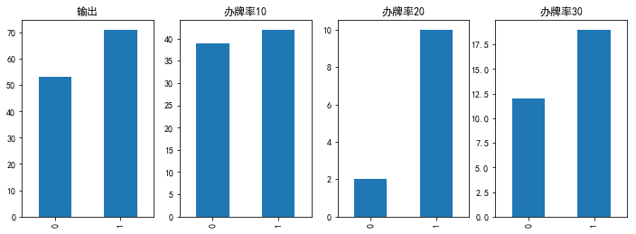

```python
fig,axes=plt.subplots(1,4,figsize=(12,4))#查看办牌率不同是否影响输出
data.输出.value_counts().sort_index().plot(kind = 'bar',ax=axes[0],title=u'输出');#这里加上sort_index()是为了统一index的顺序
for i in range(1,4):
    data[data.办牌率==i*10].输出.value_counts().sort_index().plot(kind = 'bar', ax =axes[i],title=u'办牌率{}'.format(i*10));
```

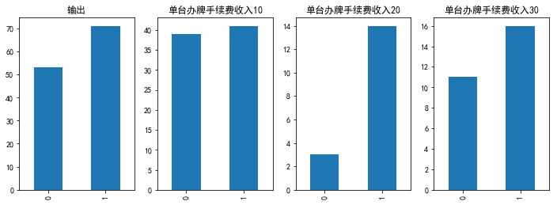

```python
fig,axes=plt.subplots(1,4,figsize=(12,4))#查看单台办牌手续费收入不同是否影响输出
data.输出.value_counts().sort_index().plot(kind = 'bar',ax=axes[0],title=u'输出');#这里加上sort_index()是为了统一index的顺序
for i in (1,2,3):
    data[data.单台办牌手续费收入==i*10].输出.value_counts().sort_index().plot(kind = 'bar', ax =axes[i],title=u'单台办牌手续费收入{}'.format(i*10));
```

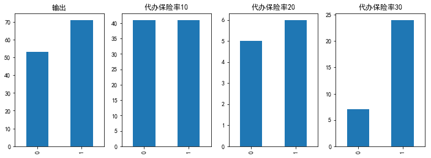

```python
fig,axes=plt.subplots(1,4,figsize=(12,4))#查看代办保险率不同是否影响输出
data.输出.value_counts().sort_index().plot(kind = 'bar',ax=axes[0],title=u'输出');#这里加上sort_index()是为了统一index的顺序
for i in range(1,4):
    data[data.代办保险率==i*10].输出.value_counts().sort_index().plot(kind = 'bar', ax =axes[i],title=u'代办保险率{}'.format(i*10));
```

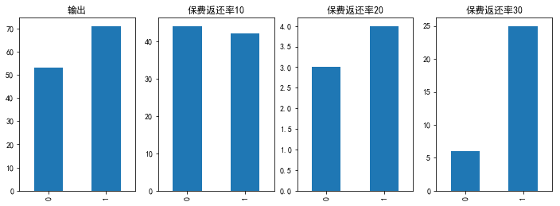

```python
fig,axes=plt.subplots(1,4,figsize=(12,4))#查看保费返还率不同是否影响输出
data.输出.value_counts().sort_index().plot(kind = 'bar',ax=axes[0],title=u'输出');#这里加上sort_index()是为了统一index的顺序
for i in range(1,4):
    data[data.保费返还率==i*10].输出.value_counts().sort_index().plot(kind = 'bar', ax =axes[i],title=u'保费返还率{}'.format(i*10));
```

通过查看以上统计图描述，最终保留了所有特征向量

```python
data1=data.iloc[:,:-1]#特征向量
```

```python
data1.columns#查看特征向量的列名，为下步进行哑变量处理那些特征最铺垫
```

```
Index(['销售类型', '销售模式', '汽车销售平均毛利', '维修毛利', '企业维修收入占销售收入比重', '增值税税负', '存货周转率',
       '成本费用利润率', '整体理论税负', '整体税负控制数', '办牌率', '单台办牌手续费收入', '代办保险率', '保费返还率'],
      dtype='object')
```

```python
data2=pd.get_dummies(data1,prefix='col_',columns=(data1.columns))#哑变量处理
```